# Simulation

Ryan Farhab

2022-10-04

This is the R markdown (rmd) exercise file that accompanies the lecture notes. It will be your sandbox! Fill in the R code chunks, experiment, and have fun!

# Introduction

### Monte Carlo Simulation: An Example

What is Monte Carlo simulation? https://www.investopedia.com/terms/m/montecarlosimulation.asp

### Concept of Seed

Learn about set.seed(): http://www.datasciencemadesimple.com/generate-sample-set-seed-function-r/

### set.seed() Example

Experiment with set.seed() to find out how it works:

```r
set.seed(123)
rnorm(10)
```

```
##  [1] -0.56047565 -0.23017749  1.55870831  0.07050839  0.12928774  1.71506499
##  [7]  0.46091621 -1.26506123 -0.68685285 -0.44566197
```

# Using Simulation for European Option Pricing

### Pricing a Call Option

Understand the call option payoff written in terms of max operator.

### Geometric Brownian Motion: A Model for Stock Price

This paper, “Geometric Brownian Motion, Option Pricing, and Simulation: Some Spreadsheet-Based Exercises in Financial Modeling”, is a good introduction to GBM:

https://epublications.bond.edu.au/ejsie/vol5/iss3/4/

It also contains spreadsheet implementation of the simulation approach.

### Simulating Geometric Brownian Motion

Define a function that returns one simulated GBM price path:

```r
GBM_path <- function(S0, mu, T, n, sigma){
  delta_t <- T/(n-1)
  S <- rep(0, n)
  S[1] <- S0

  for (i in 2:n) {
    S[i] <- S[i-1] * exp((mu - 0.5*sigma*sigma) * delta_t + sigma * rnorm(1) * sqrt(delta_t))
  }
  return(S)
}
```

### Simulate One Path

Simulate one price path and plot it:

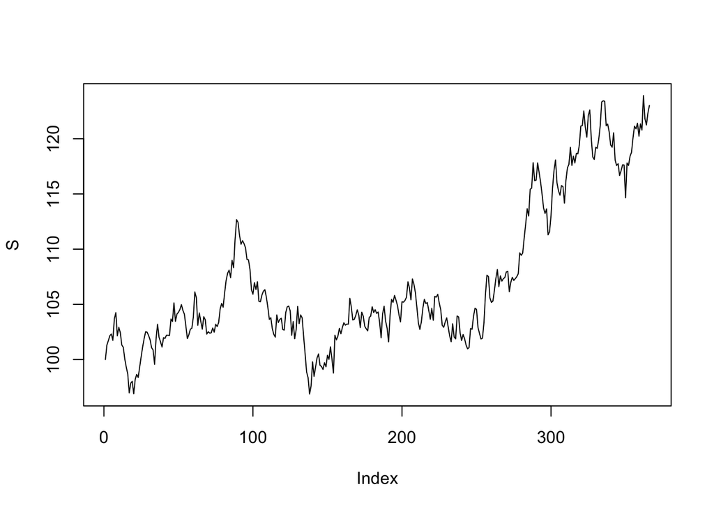

```r
S0 <- 100
mu <- 0.1
T <- 1
n <- 366
sigma <- 0.2
S <- GBM_path(S0, mu, T, n, sigma)
plot(S, t='l')
```

### Simulate Many Paths

Define the function that returns n simulated GBM price paths:

```r
GBM_n_paths <- function(S0, mu, T, n, sigma, n_paths){
  X <- matrix(rep(0, n*n_paths), nrow = n_paths)

  for (i in 1:n_paths) {
    X[i,] <- GBM_path(S0, mu, T, n, sigma)
  }
  return(X)
}
```

### Visualize the Price Paths

Plot the time series of the simulated price paths:

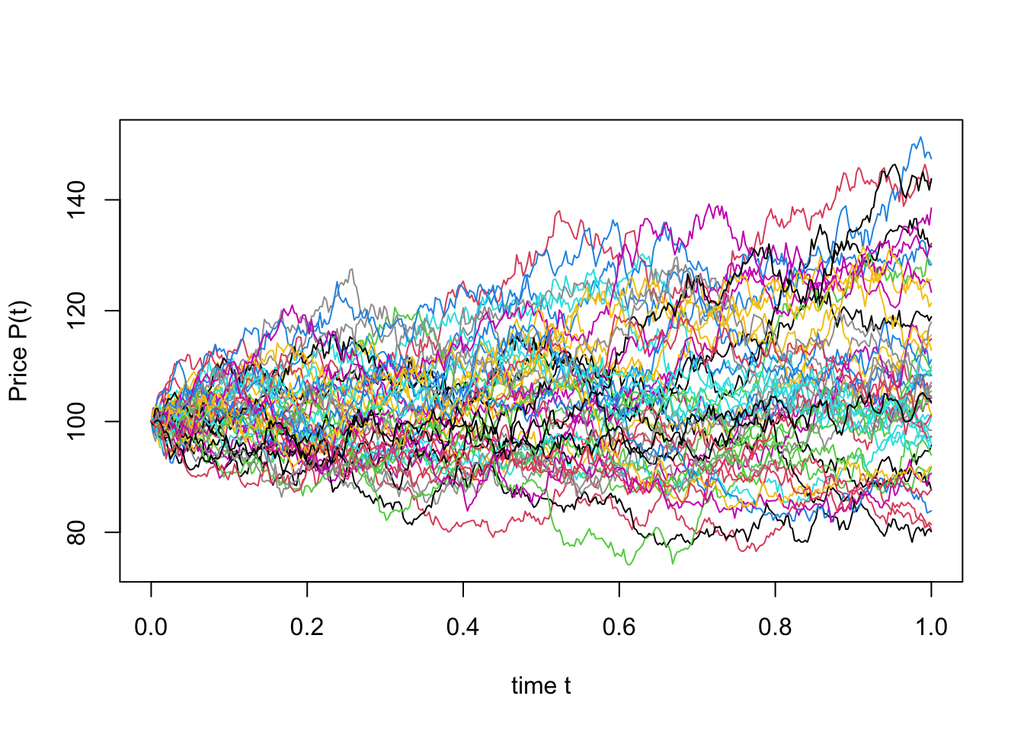

```r
n_paths <- 50
X <- GBM_n_paths(S0, mu, T, n, sigma, n_paths)
ymax <- max(X); ymin <- min(X)
t <- seq(0, T, by = T/(n-1))

plot(t, X[1,], t='l', ylim=c(ymin, ymax), col=1,
     ylab = "Price P(t)", xlab = "time t")

for (i in 2:n_paths) {
  lines(t, X[i,], t='l', ylim=c(ymin, ymax), col=i)
}
```

### Use Simulation to Price a European Call

Simulate a random sample of the prices at maturity:

```r
n_paths <- 1000
S0 <- 100
r_f <- 0.05
T <- 1
sigma <- 0.2
X_European <- GBM_n_paths(S0, mu = r_f, T, n=2, sigma, n_paths)
S_T <- X_European[, 2]
```

### The Distribution of $S_T$

Use histogram to visualize the distribution of the price at maturity:

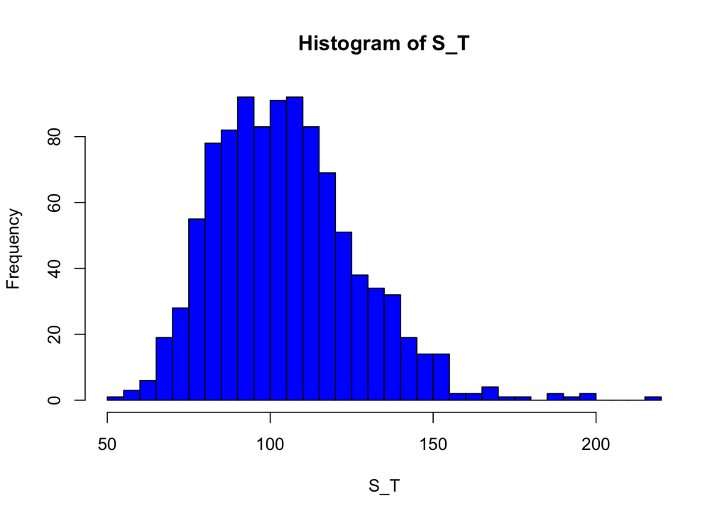

```r
hist(S_T, breaks = 50, col = 'blue')
```

### Pricing the European Call

Calculate the option value based on simulation. Experiment with the different values of n_paths.

```r
K <- 110
(European_call_value_simulation <- exp(-r_f * T) * mean(pmax(S_T - K, 0)))
```

```
## [1] 6.186808
```

### Black-Scholes Formula

Implement the Black-Scholes formula for a call option, and calculate the call option value based on this formula:

```r
BS_call <- function(S, K, r, T, sigma) {
  d1 <- (log(S/K) + (r + sigma^2/2)*T) / (sigma*sqrt(T))
  d2 <- d1 - sigma*sqrt(T)
  call_value <- S * pnorm(d1) - K*exp(-r*T)*pnorm(d2)
  return(call_value)
}

(European_call_value_BS <- BS_call(S0, K, r_f, T, sigma))
```

```
## [1] 6.040088
```

Reference: https://rpubs.com/stvrd/blackscholes

Compare the simulation result and the Black-Scholes result. How can you improve the simulation result?

# Pricing Asian Options

### Asian Options

Reference: https://en.wikipedia.org/wiki/Asian_option

### Simulate the price paths

Simulate the price paths to price the Asian option:

```r
n_paths <- 1000
S0 <- 100
r_f <- 0.05
T <- 1
sigma <- 0.2
n <- 50
X_Asian <- GBM_n_paths(S0, mu = r_f, T, n, sigma, n_paths)
```

### Calculate the Average Price

Calculate the average price for each path, and plot the histogram of the average prices:

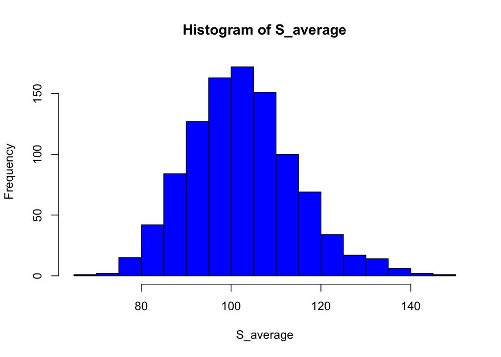

```r
S_average <- rowMeans(X_Asian)

hist(S_average, breaks = 20, col='blue')
```

### Price the Asian Call

Calculate the Asian call option value, based on discounted expected payoff:

```r
K <- 110
exp(-r_f * T) * mean(pmax(S_average - K, 0))
```

```
## [1] 1.947424
```

How does it compare to the European call option value?

Another type of Asian option uses $S_{average}$ as the strike (it is called the floating strike option), so that the payoff at maturity is:
$$\max(S_T - S_{average}, 0)$$

Can you price this option?